# First Exam Data Science for Socioeconomists Ws 24/25 - 07. February 2025

# Info on exam

There will be four different tasks with various sub-tasks and the following points:

1. MC questions - 30p
2. Code explanation - 20p
3. Regression - 22p
4. Regularization and Generalisability - 18p
- The exam consists of 90p total.
- You are not supposed to answer with handwritten code but rather with “normal” text.
- Use as many post decimal digits (“Nachkommastellen”) as stated - if NOT stated, use two

**Important**

If you are not sure on the translation of a certain term from English to German please ask the exam supervisors!

# Task 1: single choice Questions (30p)

10 questions, 3p each!

**Note**

## Task 1.1

**Working with R**: Given the following matrix in R: `matrix_data <- matrix(c(1, 2, 3, 4, 5, 6), nrow = 2, ncol = 3, byrow = TRUE)`. Which of the following R code lines correctly returns the number of columns in this matrix?

1. ⬜ `ncol(matrix_data)`
2. ⬜ `nrow(matrix_data)`
3. ⬜ `length(matrix_data)`
4. ⬜ `dim(matrix_data)[2]`

## Task 1.2

**Algorithms**: What is the main purpose of an algorithm?

1. ⬜ Database management
2. ⬜ Automatic generation of graphics
3. ⬜ Solving a problem through a sequence of steps
4. ⬜ Implementation of hardware components

## Task 1.3

**Model validation**: What is a fundamental step in model validation in data science?

1. ⬜ Train the model
2. ⬜ Collect data
3. ⬜ Verify the model performance with new data
4. ⬜ Save the model in a database

## Task 1.4

Which of the following methods is least effective for **simplifying a model or reducing overfitting**?

1. ⬜ Feature selection to remove irrelevant or redundant features.
2. ⬜ Regularization techniques like Lasso and Ridge regression to penalize large coefficients.
3. ⬜ Increasing the number of features with techniques like feature engineering and feature expansion to capture more information about the data.
4. ⬜ Pruning techniques in decision trees to remove branches that have little importance.

## Task 1.5

What is the main objective of regularization as seen in **Ridge/Lasso regression**?

1. ⬜ To improve training speed by reducing the dataset size.
2. ⬜ To handle missing values in the dataset effectively.
3. ⬜ To prevent overfitting by penalizing model coefficients under assumption of a specific loss function.
4. ⬜ To increase the complexity of the model for better accuracy.

## Task 1.6

What type of problem is **logistic regression** primarily used to solve?

1. ⬜ Regression problems where the target variable is continuous.
2. ⬜ Classification problems where the target variable is categorical.
3. ⬜ Clustering problems where the data is grouped into clusters.
4. ⬜ Dimensionality reduction problems.

## Task 1.7

Which of the following metrics is most commonly used to evaluate the **goodness of fit in a linear regression model**?

1. ⬜ Accuracy
2. ⬜ Mean Squared Error (MSE)
3. ⬜ F1-score
4. ⬜ Precision

## Task 1.8

In Ordinary Least Squares (OLS) linear regression, **which of the following does Residual Sum of Squares (RSS) measure**? The equation for RSS is:

$$\begin{equation}
RSS = \sum_{i=1}^{n} (y_i - \hat{y}_i)^2
\end{equation}$$

1. ⬜ The sum of the squared differences between the observed values and the values predicted by the model.
2. ⬜ The total variation in the dependent variable around its mean.
3. ⬜ The sum of the squared differences between the observed values and the mean of the dependent variable.
4. ⬜ The proportion of the variance in the dependent variable explained by the independent variable(s).

## Task 1.9

Which of the following are **NOT** considered good practices in data analysis and coding?

1. ⬜ **Transparency** ensures that the analysis process, including the code and assumptions, is documented clearly so others can follow and understand the methodology.
2. ⬜ **Reproducibility** guarantees that anyone with the same data and code can obtain the same results, supporting consistent and reliable findings.
3. ⬜ **Validity** refers to using appropriate methods to ensure that the conclusions drawn from the analysis accurately reflect the problem being studied.
4. ⬜ **Efficiency** emphasizes optimizing code for speed, even if it results in a more complex or harder-to-read structure.

## Task 1.10

**Model performance**: Which term describes the ability of a model to perform well on unseen data?

1. ⬜ Overfitting
2. ⬜ Generalization
3. ⬜ Data cleaning
4. ⬜ Underfitting

# Task 2: Code explanation (20p in total)

We will work with `happiness_income_data`. This dataset includes information about different countries and income, satisfaction of the inhabitants, the GDP, income inequality and other variables. Below you get an extensive data description and the tasks.

[output not shown]

### Data Description:

The dataset consists of 111 observations. You will work with a subset in task 2.1, and the full data set in task 2.2 and task 2.

| name | valuetype | scale | explanation |
| --- | --- | --- | --- |
| adjusted_satisfaction | numeric | 0 to 100 | lower values indicate lower life satisfaction, higher values indicate higher life satisfaction |
| avg_income | numeric | 0$ to thousands of $ | average annual income in $ |
| median_income | numeric | 0$ to thousands of $ | median annual income in $ |
| income_inequality | numeric | 0 to 100 | income inequality, lower values indicate a lower inequality, higher values indicate a higher inequality |
| happyScore | numeric | 0-10 | lower values indicate a lower overall happiness, higher values indicate a higher overall happiness |
| gdp | numeric |  | GDP in billions of $ (Milliarden auf deutsch) |
| country | character | - | country name |

## Task 2.1 (14p)

2.1.1. Below is a subset of the dataset happiness_income_data. The code applies steps for data cleaning (i.e., dealing with missing values and outliers). **Follow the steps in the code and update the table by hand. Your final table should be happiness_data_clean** (8p).

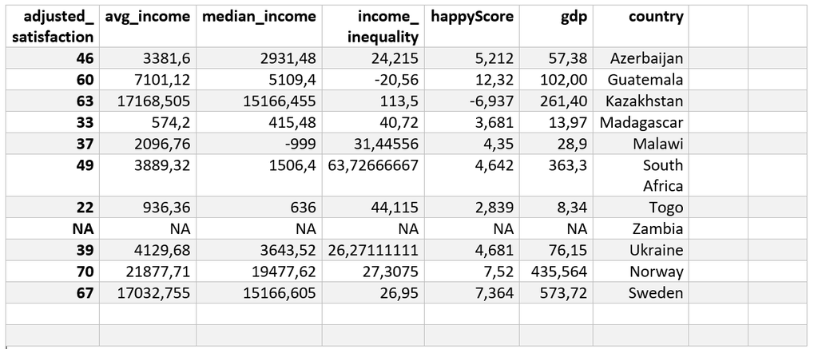

```r
   # load("happiness_income_data.RData") #loading data
load("happiness_income_data.RData")

happiness_income_data$happyScore <- ifelse(
  happiness_income_data$happyScore > 10, NA, happiness_income_data$happyScore
)

happiness_income_data$median_income <- ifelse(
  happiness_income_data$median_income < 0, NA, happiness_income_data$median_income
)

happiness_income_data$income_inequality <- ifelse(
  happiness_income_data$income_inequality < 0 |
  happiness_income_data$income_inequality > 100, NA, happiness_income_data$income_inequality
)

happiness_income_data_clean <- na.omit(
  happiness_income_data
)
```

2.1.2. Did you **remove singular values and/or rows and/or columns**? If you did so, explain why.(2p)

2.1.3. Did you **change the content or name of singular values and/or rows and/or columns**? If you did so, explain why. (2p)

2.1.3. After applying the code: **Are any values left that could potentially lead to problems**? If so, how could we fix that problem (answer verbally, no code needed)? (2p)

## Task 2.2 (6p)

[output not shown]

```r
options(scipen=999)
model1 <- lm(adjusted_satisfaction ~ avg_income, happiness_income_data_clean)
summary(model1)
```

```
Call:
lm(formula = adjusted_satisfaction ~ avg_income, data = happiness_income_data_clean)

Residuals:
     Min       1Q   Median       3Q      Max
-21.7157  -5.6274  -0.6043   4.8905  23.8228

Coefficients:
              Estimate Std. Error t value            Pr(>|t|)
(Intercept) 39.3791816  1.1945606   32.97 <0.0000000000000002 ***
avg_income   0.0014197  0.0001282   11.08 <0.0000000000000002 ***
---
Signif. codes:  0 '***' 0.001 '**' 0.01 '*' 0.05 '.' 0.1 ' ' 1

Residual standard error: 8.633 on 101 degrees of freedom
Multiple R-squared:  0.5485,    Adjusted R-squared:  0.5441
F-statistic: 122.7 on 1 and 101 DF,  p-value: < 0.00000000000000022
```

2.2.1. Explain **which of these graphs illustrates the results of the linear regression (model1) best** and **why** it is the best illustration? (3p)

2.2.2. Why are the **other graphics not suitable**? (1p each)

Graph 1

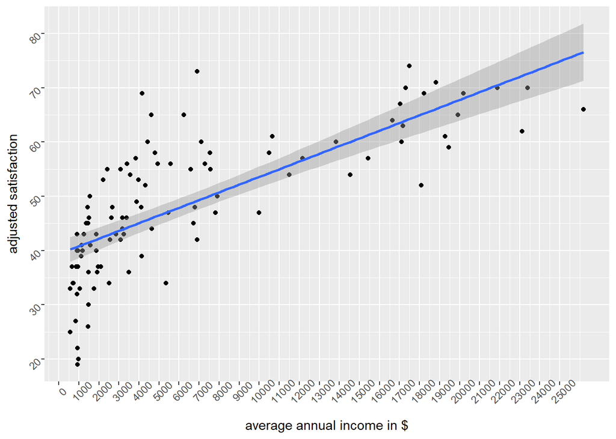

Graph 2

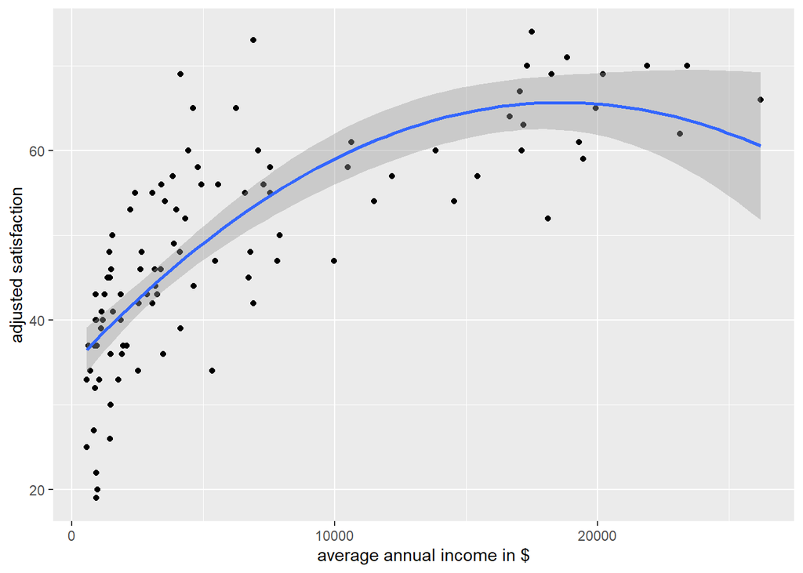

Graph 3

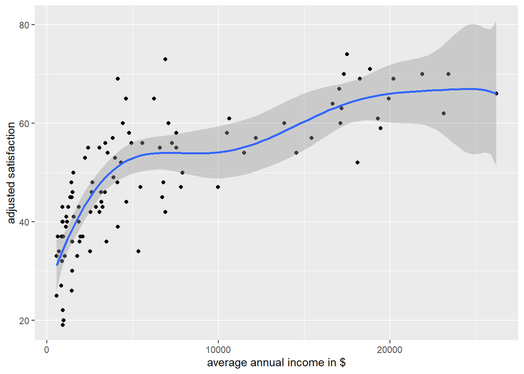

Graph 4

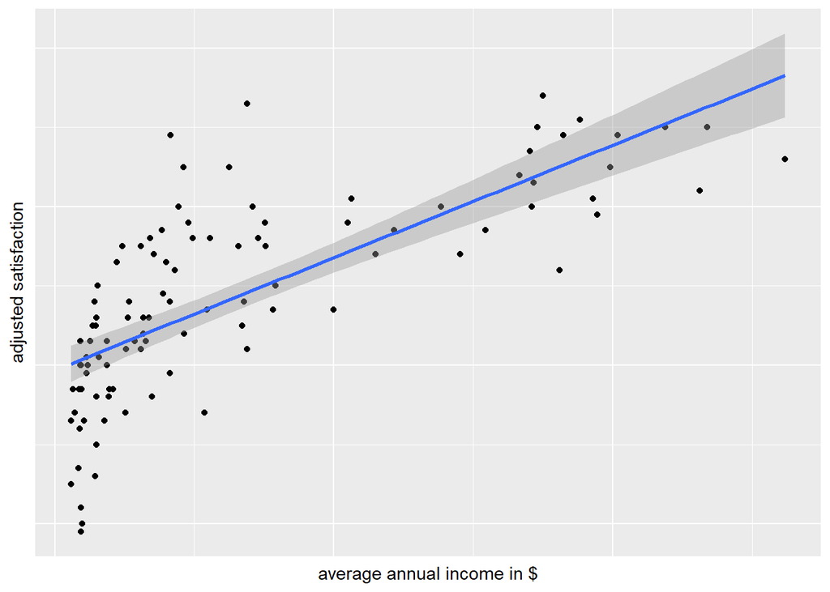

# Task 3: Regression (22p in total)

## Task 3.2 (2p)

**Explain** each model in your own words

## Task 3.3 (4p)

Write down the **mathematical formula** for each of the models

## **Task 3.4 (6p)**

**Interpret the coefficients for the linear model** (value, meaning, significance), use five post decimal positions

```r
options(
  scipen = 999
)

linear_model <- lm(
  happyScore ~ income_inequality + gdp + median_income,
  data = happiness_income_data_clean
)

summary(
  linear_model
)
```

```
Call:
lm(formula = happyScore ~ income_inequality + gdp + median_income,
    data = happiness_income_data_clean)

Residuals:
     Min       1Q   Median       3Q      Max
-1.90821 -0.52398  0.02605  0.50797  1.92943

Coefficients:
                      Estimate   Std. Error t value             Pr(>|t|)
(Intercept)        3.244930846  0.436596604   7.432      0.0000000000386 ***
income_inequality  0.031412802  0.010059035   3.123              0.00235 **
gdp               -0.000008244  0.000028057  -0.294              0.76952
median_income      0.000183292  0.000015397  11.905 < 0.0000000000000002 ***
---
Signif. codes:  0 '***' 0.001 '**' 0.01 '*' 0.05 '.' 0.1 ' ' 1

Residual standard error: 0.7639 on 99 degrees of freedom
Multiple R-squared:  0.6172,    Adjusted R-squared:  0.6056
F-statistic: 53.21 on 3 and 99 DF,  p-value: < 0.00000000000000022
```

## Task 3.5. (6p)

**Interpret the coefficients for the logistic model** (value, meaning, significance), use five post decimal positions. Are those coefficients the same as marginal effects?

```r
options(
  scipen = 999
)#creates readable numbers

# Logistic regression for "happy country" or not
happiness_income_data_clean$high_happyScore <- ifelse(
  happiness_income_data_clean$happyScore >= 7, 1, 0
)

logistic_model <- glm(
  high_happyScore ~ income_inequality + gdp + median_income,
  family = binomial,
  data = happiness_income_data_clean
)

summary(
  logistic_model
)
```

```
Call:
glm(formula = high_happyScore ~ income_inequality + gdp + median_income,
    family = binomial, data = happiness_income_data_clean)

Coefficients:
                     Estimate  Std. Error z value Pr(>|z|)
(Intercept)       -9.03619460  3.65814458  -2.470 0.013505 *
income_inequality  0.10122501  0.07170045   1.412 0.158016
gdp               -0.00003626  0.00012377  -0.293 0.769583
median_income      0.00039288  0.00011333   3.467 0.000527 ***
---
Signif. codes:  0 '***' 0.001 '**' 0.01 '*' 0.05 '.' 0.1 ' ' 1

(Dispersion parameter for binomial family taken to be 1)

    Null deviance: 81.883  on 102  degrees of freedom
Residual deviance: 45.760  on  99  degrees of freedom
AIC: 53.76

Number of Fisher Scoring iterations: 7
```

# Task 4: Regularization and Generalizability (18p in total)

Given the linear regression models below,

happyScore = $\beta_1$ income_inequality + $\beta_2$ gdp + $\beta_3$ median_income

answer the following questions:

## Task 4.1 Regularization: Ridge and Lasso regression (6p)

4.1.1 Suppose you want to use Ridge or Lasso regression to reduce overfitting of the model to training data. **Say, variables income_inequality and median_income are highly correlated. How might the coefficients (**$\beta_1$ **and** $\beta_3$**) change if you use ridge regression?** (3p)

4.1.2 **What about Lasso regression?** (3p)

## Task 4.2 Generalizability Testing (6p)

4.2.1 Generalizability refers to models’ ability to make correct predictions on unseen data. Given the happiness_income_data_clean dataset, **please describe a method to evaluate the generalizability of the linear regression model.** (2p)

4.2.2 Given the following results from a 5-fold cross-validation, **calculate the average R-squared value**. (2p)

| **Fold** | **R-squared Value** |
| --- | --- |
| Fold 1 | 0.85 |
| Fold 2 | 0.85 |
| Fold 3 | 0.84 |
| Fold 4 | 0.83 |
| Fold 5 | 0.83 |

4.2.3. What does this average, combined with the consistency of the fold results, tell you about the **model’s ability to generalize**? (2p)

## Task 4.3 **Decision Tree Construction (6p)**

Given the following dataset for predicting happiness score (cat_HappyScore) based on cat_GDP and cat_income_inequality (all variables are categorical variables), **draw the decision tree you would construct for predicting HappyScore based on GDP and Income Inequality.** (6p)

Please note: gdp, income_inequality and HappyScore as you know them from the dataset in task 2 and 3 were transformed into categorical variables (indicated by the prefix `cat_`)

| **cat_GDP** | **cat_income_inequality** | **cat_HappyScore** |
| --- | --- | --- |
| Low | High | Low |
| Low | Medium | High |
| Low | Low | High |
| Medium | High | Low |
| Medium | Medium | Low |
| Medium | Low. | Low |
| High | High | Low |
| High | Medium | Low |
| High | Low | High |